# Project #3 Artificial intelligance (Naive Bayes)

# (spring 2022)

```
Amirmahdi Ansaripour

Student ID: 810198358
```

Approach:

Classificing texts based on their contexts

Description:

At first some texts are given to us as inputs or training set. We're going to implement a Naive Bayes classification based on the training set.

The details are described inside the article, but what we're doing is generally finding type of a text using conditional probability and Bayes rule.

The project's samples are all in Persian language.

### Defining global variables and libraries

```python
import pandas as pds
import operator as op
from matplotlib import pyplot as plot
from hazm import *
from math import log



ZERO = 0.000000000000000000000000000000000000000000000000000000000000000000000000000000000000000000000000000000001
dataframe = pds.read_csv('train.csv')
testframe = pds.read_csv('test.csv')
types = ['هنر و سینما',
         'علم و تکنولوژی',
         'بازی ویدیویی',
         'سلامت و زیبایی']

# variables of training
art_and_cinema = dict()
science_and_technology = dict()
video_game = dict()
health_and_beauty = dict()
freq_table = [art_and_cinema, science_and_technology, video_game, health_and_beauty]
words_in_each_class = [0] * len(types)
non_repeated = [0] * len(types)

# variables of testing
y_true = []
y_pred = []
total = len(testframe)
correct_detected = 0
truly_detected = [0] * len(types)
wrongly_detected = [0] * len(types)
wrongly_not_detected = [0] * len(types)
wrongly_labeled = []


lemmatizer = Lemmatizer()
normalizer = Normalizer()
stemmer = Stemmer()
```

### Defining Stopwords

```python
stop_words = stopwords_list()
stop_words.append(')')
stop_words.append('(')
stop_words.append(',')
stop_words.append(':')
stop_words.append('.')
stop_words.append('!')
stop_words.append('?')
stop_words.append('ـ')
stop_words.append('-')
stop_words.append('"')
stop_words.append('#')
stop_words.append('*')
stop_words.append('...')
stop_words.append('....')
stop_words.append('/')
stop_words.append('[')
stop_words.append(']')
stop_words.append('،')
stop_words.append('؛')
stop_words.append('؟')
stop_words.append('«')
stop_words.append('»')
stop_words.append('…')
stop_words.append('سال')
stop_words.append('قرار')
stop_words.append('آن‌ها')
stop_words.append('است‌')
```

### Preprocessing Words Using Hazm Library

```python
print("Output of normalizing : ")
normalizer.normalize(dataframe["content"][0][0:100])
```

```
Output of normalizing :
```

```
'فیلم\u200cهای در حال اکران؛ موزیکال شاد خاله قورباغه برای بزرگسالان و بچه\u200cها فیلم خاله قورباغه را شاید از'
```

```python
print("Output of tokenizing : ")
word_tokenize(dataframe["content"][0])
```

```
Output of tokenizing :
```

```
['فیلم\u200cهای',
 'در',
 'حال',
 'اکران',
 '؛',
 'موزیکال',
 'شاد',
 'خاله',
 'قورباغه',
 'برای',
 'بزرگسالان',
 'و',
 'بچه\u200cها',
 'فیلم',
 'خاله',
 'قورباغه',
 'را',
 'شاید',
 'از',
 'زمان',
 'تلویزیون',
 'یادتان',
 'باشد',
 '.',
 'کاراکتر',
 'قورباغه',
 'بامزه\u200cای',
 'که',
 'پرحرف',
 'بود',
 'و',
 'دل',
 'مهربانی',
 'داشت',
 'ولی',
 'مدام',
 'خرابکاری',
 'می\u200cکرد',
 '.',
 'قبل\u200cتر',
```

[output cut: 434 more lines]

```
 'است',
 '.',
 'بیشتر',
 'بخوانید',
 ':',
 'راهنمای',
 'فیلم\u200cهای',
 'روی',
 'پرده',
 '؛',
 'زن',
 'معتاد',
 'متفاوت',
 'در',
 'دارکوب']
```

```python
print("Output of stemming : ")
print(stemmer.stem("کتاب هایم"))
print(stemmer.stem("انسانیت"))
print(stemmer.stem("سلام"))
```

```
Output of stemming :
کتاب
انسان
سلا
```

```python
print("Output of lemmatizing : ")
print(lemmatizer.lemmatize("رفتم"))
print(lemmatizer.lemmatize("می‌روند"))
print(lemmatizer.lemmatize("خوردند"))
```

```
Output of lemmatizing :
رفت#رو
رفت#رو
خورد#خور
```

```
1) Explain how lemmatizing and stemming work and change their input.
```

The first point that should be mentioned is that the hazm library and it's functions are commonly used for Persian language, so some parts of the answers are directly related to the language and its grammar.

The examples above indicate that lemmatizing's usage is to find the root of verbs given in it's input and replacing them with the root. It will help us when a verb is used in different tenses but the tense doesn't matter in our classification.

Stemming is about eliminating suffix and profix from a word and like lemmatizing, it's useful in the same way as lemmatizing is because leads to the root. But there is a big problem with the function that is some words that do not have any suffix or prefix are changed either. This causes inacuracy and is undesirable.

### Training The Naive Bayes

After getting familiar with methods of preprocessing our input, it's time to train our model and learn it to detect which words are most commonly used in each type of article.

At last, some bar charts are plotted to represent the frequencies

2) In the below formula, explain how each parameter is defined in our problem.

```
                    P(c|x) = P(x|c) * P(c) / P(x)
```

x : a new word

c : article type

P(x|c): Probability of seeing word x in condition that we know the article classification (c). (Posterior)

P(c|x): Probability of being c as classification of an article, in condition that we know a specific word in that article. (Likelihood)

P(c) : Probability of seeing an article whose classification is c. this probability is equal for all types as mentioned in the description that there are equal number of rows for each type.

P(x) : Probability of seeing word x.

```python
def preprocess(text, index):
    tokens = word_tokenize(text)
    result = []
    for i in range(0, len(tokens)):
#         word = stemmer.stem(tokens[i])
        if (tokens[i] not in stop_words):
#             root == Lemmatizer().lemmatize(tokens[i])
            result.append(tokens[i])
    return result

def Train():
    for i in range(len(dataframe)):
        if (isinstance(dataframe.iloc[i, 0], float)):
            continue
        words = preprocess(dataframe.iloc[i, 0], i)
        label = dataframe.iloc[i, 1]
        for word in words:
            if(label == types[0]):
                art_and_cinema[word] = art_and_cinema.get(word, 0) + 1
                words_in_each_class[0] += 1
            elif (label == types[1]):
                science_and_technology[word] = science_and_technology.get(word, 0) + 1
                words_in_each_class[1] += 1
            elif (label == types[2]):
                video_game[word] = video_game.get(word, 0) + 1
                words_in_each_class[2] += 1
            elif (label == types[3]):
                health_and_beauty[word] = health_and_beauty.get(word, 0) + 1
                words_in_each_class[3] += 1
```

```python
def plot_chart(items, title):
    sorteditems = dict(sorted(items, key = op.itemgetter(1), reverse = True)[:5])
    keys = sorteditems.keys()
    values = sorteditems.values()
    plot.bar(keys, values)
    plot.xlabel('WORD')
    plot.ylabel('FREQUENCY')
    plot.title(title)
    plot.show()
```

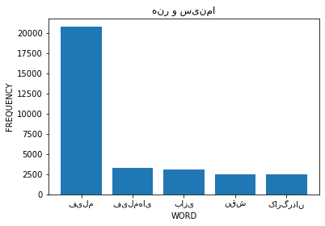

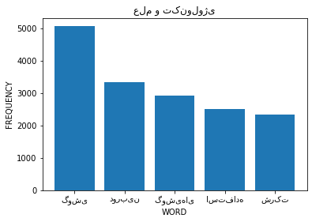

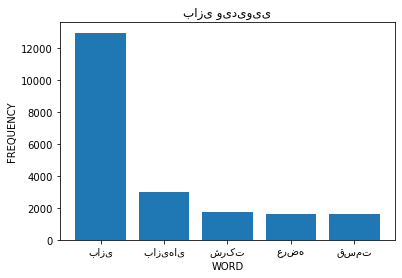

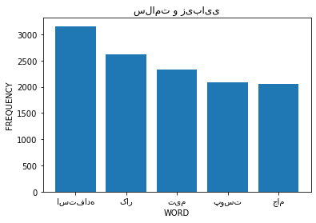

```python
Train()
for i in range(len(types)):
    non_repeated[i] = len(freq_table[i].keys())
    plot_chart(freq_table[i].items(), types[i])
```

## Bigrams and how they work

3) Exemplify two sentences having a common word but each word has a different meaning. This issue certainly decreases our accuracy in training. How using bigrams will help us solving the matter.

او با قوم و خویش خود به مسافرت رفت کتاب "شبی با خویش" را خواندم

In the first sentence, خویش means "relatives" and in the second one, means "self". The meanings are detected only by refering to the context, so unigrams aren't sufficient in this case and bigrams (or maybe trigrams) should be used. In this example قوم and it's adjacency to خویش is enough to detect the meaning.

## Additive smothing

4) Sometimes, in your training sets, there are some words that aren't appeared in all sets. In addition, in some cases the input may contain a word that isn't found in any set. How this issue influences the Naive Bayes procedure?

In the two cases above, imagine the word is x10, no we have:

```
P(c | X) = [P(x1 | c) . P(x2 | c) ... P(x10 | c) ... P(xn | c)] * P(c)
P(x10 | c) = 0   =>  P(c | X) = 0
```

So because of only one word, the whole probability that the article is of c type gets zero.

5) Explain how additive smothing solves the problem in the previous question.

Additive smothing simply adds an alpha coefficient in the way below: (If alpha equals zero, no additive smothing is used)

```
P(xi | c) = count(xi, c) + alpha / ∑ count(xi, c) + alpha.|V|
```

Where V is the unique words causing the problem above.

In this way, probability of unique words never equals zero and the total probability consquently.

## Evaluation

7) When evaluating a classification, some parameters are considered. Two of them are precision and accuracy:

```
Precision = |Correct detected classes| / |All detected classes| (including wrong)
Recall = |Correct detected classes| / |Total classes|
```

Explain why both of these parameters are vital for our estimation.

Imagine a classification which detected all samples having the same type. this estimation has 100% recall but lacks precision.

For the second case, we have a classification which for example detected only one هنر و سینما type between hundreds of samples. This assortment seems to be very precise but in reality, it has missed many other samples with the same type.

8) Besides the normal method of getting average over data, another method is used named F1 whose formula is described below. How they differ?

```
    F1 = 2 * Precision * Recall / (Precision + Recall)
```

From the previous question, we can conclude that there is a trade-off between precision and recall; Hence, there should be a quantity that represents and is affected by both of them. Imagine a classification in which articles are of sort A or not; After assortment, we have this results:

True (A) : detected A truly

False (A) : detected A wrongly

```
Precision = True(A) / True(A) + False(A)
Recall = True(A) / True(A) + False(~A)
// False(~A) means we wrongly missed a sample of type A
```

After simplifing F1 and cancelation in numerator and denominator, we'll have:

```
F1 = True(A) / True(A) + ((False(A) + False(~A)) / 2)
Average = True(A) / True(A) + False(~A)      // denominator equals number in test
```

So if we detect alot of A's samples wrongly, they won't show themselves in average but influnce F1 parameter.

9) In our case we have more than one classes to detect. So we should use multi-class metrics to evalute our estimation. Search about it and explain the three most important ways of getting average in that(Micro, Macro, Weighted).

Micro : It's difference with normal F1 is that we have a summation in both numerator and denominator over all classes.

Macro : It calculates F1 for every single class and lastly, gets an un-weighted average on them. It doesn't care of different classes' proportions in the input.

Weighted : Similar to Macro but the average is weighted.

## Testing The Classification

When our model has sufficiently learned how to detect article types, we should test it.

```python
def test_new_input(text, k):
    words = word_tokenize(text)
    probs = [0] * len(types)
    for word in words:
        if word in stop_words:
            continue
        for i in range(len(types)):
            probs[i] += log((freq_table[i].get(word, 0) + k) / (words_in_each_class[i] + k * non_repeated[i]))
    return probs
```

```python
def Test(k):
    for i in range(len(testframe)):
        probs_of_input = test_new_input(testframe.iloc[i, 0], k)
        label = testframe.iloc[i, 1]
        max_value = max(probs_of_input)
        detected_index = probs_of_input.index(max_value, 0)
        label_index = types.index(label, 0)
        global y_pred
        y_pred.append(detected_index)
        global y_true
        y_true.append(label_index)
        if (label_index == detected_index):
            global correct_detected
            correct_detected += 1
            global truly_detected
            truly_detected[detected_index] += 1
        else:
            global wrongly_detected
            wrongly_detected[detected_index] += 1
            global wrongly_not_detected
            wrongly_not_detected[label_index] += 1
            if k != ZERO :
                global worngly_labeled
                wrongly_labeled.append((i, detected_index))
```

```python
def other_means(precisions, recalls, F1s):
    sum_of_truly_detected = sum(truly_detected)
    sum_of_wrongly_detected = sum(wrongly_detected)
    sum_of_wrongly_not_detected = sum(wrongly_not_detected)
    micro_precision = sum_of_truly_detected / (sum_of_truly_detected + sum_of_wrongly_detected)
    micro_recall = sum_of_truly_detected / (sum_of_truly_detected + sum_of_wrongly_not_detected)
    micro_F1 = 2 * micro_recall * micro_precision / (micro_precision + micro_recall)
    print("Micro precision : ", micro_precision)
    print("Micro recall : ", micro_recall)
    print("Micro F1 : ", micro_F1, '\n\n')
    macro_precision = sum(precisions) / len(types)
    macro_recall = sum(recalls) / len(types)
    macro_F1 = sum(F1s) / len(types)
    print("Macro precision : ", macro_precision)
    print("Macro recall : ", macro_recall)
    print("Macro F1 : ", macro_F1, '\n\n')
    freqs = [0] * len(types)
    for i in range(len(testframe)):
        label = testframe.iloc[i, 1]
        freqs[types.index(label, 0)] += 1
    weighted_precision = 0
    weighted_recall = 0
    weighted_F1 = 0
    for i in range(len(freqs)):
        weighted_precision += (freqs[i] * precisions[i])
        weighted_recall += (freqs[i] * recalls[i])
        weighted_F1 += (freqs[i] * F1s[i])
    print("Weighted precision : ", weighted_precision / total)
    print("Weighted recall : ", weighted_recall / total)
    print("Weighted F1 : ", weighted_F1 / total, '\n\n')
```

```python
def reset():
    global correct_detected
    correct_detected = 0
    global truly_detected
    truly_detected = [0] * len(types)
    global wrongly_detected
    wrongly_detected = [0] * len(types)
    global wrongly_not_detected
    wrongly_not_detected = [0] * len(types)
    global y_true
    y_true = []
    global y_pred
    y_pred = []

def evaluate():
    precisions = [0] * len(types)
    recalls = [0] * len(types)
    F1s = [0] * len(types)
    accuracy = correct_detected / total
    print("Accuracy : ", accuracy , '\n\n')
    for i in range(len(types)):
        precisions[i] = truly_detected[i] / (truly_detected[i] + wrongly_detected[i])
        recalls[i] = truly_detected[i] / (truly_detected[i] + wrongly_not_detected[i])
        F1s[i] = 2 * precisions[i] * recalls[i] / (precisions[i] + recalls[i])
        print("Label : ", types[i])
        print("Precision : ", precisions[i])
        print("Recall : ", recalls[i])
        print("F1 : ", F1s[i], '\n\n\n')
    other_means(precisions, recalls, F1s)
```

### Part 1: Using additive smoothing

```python
print("Using additive smoothing\n")
reset()
Test(1)
evaluate()
```

```
Using additive smoothing

Accuracy :  0.9588528678304239


Label :  هنر و سینما
Precision :  0.9580838323353293
Recall :  0.9580838323353293
F1 :  0.9580838323353293



Label :  علم و تکنولوژی
Precision :  0.9540636042402827
Recall :  0.9747292418772563
F1 :  0.9642857142857143



Label :  بازی ویدیویی
Precision :  0.96875
Recall :  0.9441624365482234
F1 :  0.9562982005141389



Label :  سلامت و زیبایی
Precision :  0.95625
Recall :  0.9503105590062112
F1 :  0.9532710280373832



Micro precision :  0.9588528678304239
Micro recall :  0.9588528678304239
Micro F1 :  0.9588528678304239


Macro precision :  0.959286859143903
Macro recall :  0.956821517441755
Macro F1 :  0.9579846937931414


Weighted precision :  0.9589471550804965
Weighted recall :  0.9588528678304239
Weighted F1 :  0.9588211020853453
```

```python
print("Tested by classification report\n\n")
from sklearn.metrics import classification_report
print(classification_report(y_true, y_pred, target_names=types))
```

```
Tested by classification report


                precision    recall  f1-score   support

   هنر و سینما       0.96      0.96      0.96       167
علم و تکنولوژی       0.95      0.97      0.96       277
  بازی ویدیویی       0.97      0.94      0.96       197
سلامت و زیبایی       0.96      0.95      0.95       161

      accuracy                           0.96       802
     macro avg       0.96      0.96      0.96       802
  weighted avg       0.96      0.96      0.96       802
```

### Part 2: Without additive smoothing

```python
print("Not using additive smoothing \n")
reset()
Test(ZERO)
evaluate()
```

```
Not using additive smoothing

Accuracy :  0.9376558603491272


Label :  هنر و سینما
Precision :  0.9213483146067416
Recall :  0.9820359281437125
F1 :  0.9507246376811593



Label :  علم و تکنولوژی
Precision :  0.9730769230769231
Recall :  0.9133574007220217
F1 :  0.9422718808193669



Label :  بازی ویدیویی
Precision :  0.973404255319149
Recall :  0.9289340101522843
F1 :  0.9506493506493507



Label :  سلامت و زیبایی
Precision :  0.8636363636363636
Recall :  0.9440993788819876
F1 :  0.9020771513353115



Micro precision :  0.9376558603491272
Micro recall :  0.9376558603491272
Micro F1 :  0.9376558603491272


Macro precision :  0.9328664641597944
Macro recall :  0.9421066794750015
Macro F1 :  0.9364307551212971


Weighted precision :  0.9404159215398511
Weighted recall :  0.9376558603491272
Weighted F1 :  0.9380207841928
```

```python
print("Tested by classification report\n\n")
from sklearn.metrics import classification_report
print(classification_report(y_true, y_pred, target_names=types))
```

```
Tested by classification report


                precision    recall  f1-score   support

   هنر و سینما       0.92      0.98      0.95       167
علم و تکنولوژی       0.97      0.91      0.94       277
  بازی ویدیویی       0.97      0.93      0.95       197
سلامت و زیبایی       0.86      0.94      0.90       161

      accuracy                           0.94       802
     macro avg       0.93      0.94      0.94       802
  weighted avg       0.94      0.94      0.94       802
```

11) How do additive and non-additive outputs differ?

Using additive smoothing, the outputs are seemed to be better (more precise, more recalled)

12) Show 5 samples in the input that your model has detected wrongly. What reasons caused this misdetection?

The examples are shown below. The reason is that some frequently used words in a class are included in another one. So the general idea differs from some words used in the context.(First three examples are associated to this issue)

Another reason explained earlier is using unigrams. For example the word بازی both means (playing a role) and (playing game), first one is about art and cinema and the second is about vedio games. So it's probable that these two types get mistaken. (Forth example)

Another reason is that the test uses words that aren't used sufficiently in our training classes, so we can't exactly say which type relates to that.(Fifth)

```python
for i in range(5):
    (pos_in_test, our_detection) = wrongly_labeled[i]
    print("Our detection : ", types[our_detection])
    print("True class : ", testframe.iloc[pos_in_test, 1])
    print(testframe.iloc[pos_in_test, 0], "\n\n\n")
```

```
Our detection :  علم و تکنولوژی
True class :  سلامت و زیبایی
این افزونه‌ موبایل با دقت ۹۹ درصد سرطان را تشخیص می‌دهد محققان توانسته‌اند یک طیف سنج قابل حمل برای تلفن‌های همراه هوشمند تولید کنند که می‌تواند با دقت ۹۹ درصد سرطان را تشخیص دهد و به پزشکان اجازه می‌دهد که از بیماری مریض‌شان باخبر شوند. این دستگاه با بررسی کردن نمونه بافت اینترلوکین ۶ که یکی از این…



Our detection :  علم و تکنولوژی
True class :  هنر و سینما
دیزنی به کمک دوربین‌های نوکیا، محتوای واقعیت مجازی می‌سازد نوکیا سال گذشته از یک دوربین واقعیت مجازی به اسم OZO VR رونمایی کرد. این دوربین با قیمت ۶۰ هزار دلاری‌اش، اصلا به درد فیلم‌بردارهای آماتور نمی‌خورد و برای استودیوهای فیلم‌سازی و فیلم‌برداران حرفه‌ای طراحی شده است. استودیوی فیلم‌سازی دیزنی هم…



Our detection :  علم و تکنولوژی
True class :  بازی ویدیویی
Ryzen Threadripper: قوی‌ترین پردازنده‌های AMD شرکت AMD در طی یک کنفرانس خبری، جزییات مربوط به جدیدترین پردازنده‌های گرافیکی خود، یعنی کارت‌های سری RX Vega را مشخص کرد. در کنار معرفی این کارت‌های گرافیکی، AMD هم‌چنین از پردازنده‌های اصلی خود گفت. این شرکت برنامه‌های بزرگی برای پردازنده‌های Ryzen Thre…



Our detection :  بازی ویدیویی
True class :  هنر و سینما
آلیسیا ویکاندر در نقش لارا کرافت آلیسیا ویکاندر (Alicia Vikander) به عنوان هنرپیشه‌ی شخصیت لارا کرافت (Lara Croft) در فیلم جدید توم‌ریدر (Tomb Raider) به ایفای نقش می‌پردازد‌ آلیسیا ویکاندر در بازسازی فیلم توم‌ریدر در نقش لارا کرافت قرار می‌گیرد‌ به نظر می‌رسد که ساخت فیلم جدید توم‌ریدر وارد مرحله‌ی…



Our detection :  سلامت و زیبایی
True class :  علم و تکنولوژی
همه چیز درباره ارزش پول (داستان پول – قسمت ۵) اگر بدانید ارزش پولی که در گوشه خانه نگه داشته‌اید چند ماه دیگر خیلی کمتر از چیزی می‌شود که الان هست، چکار می‌کنید؟ اصلا این که می‌گوییم ارزش پول در طول زمان تغییر می‌کند یعنی چه؟ کاهش یا افزایش ارزش‌ پول، یعنی کاهش یا افزایش ارزش واحد پول یک کشور، نسبت …
```

### Conclusion

So far, we've learned a widespeard method for classifying texts and seen how it therotically and practically works.

What's more, we've measured some parameters for our model showing how accurate it is, such as recall, precision, f1, micro and macro and weighted forms of them.

Lastly, We've figured out what problems are associated with the method at general and detected the roots.

### Refrences

https://towardsdatascience.com/multi-class-metrics-made-simple-part-ii-the-f1-score-ebe8b2c2ca1

https://scikit-learn.org/stable/modules/generated/sklearn.metrics.classification_report.html